# Lettuce Demand Forecasting in Berkeley, CA and New York, NY

### Final ARIMA Model

```r
## Train best model on the entire dataset from store 12631]
best_arima11_store_12631 <- Arima(ts_store_12631, order = c(0, 1, 1), seasonal = list(order = c (1, 0, 3), period = 7), lambda = 0)
forecast_best_arima_store_12631 <- forecast(best_arima11_store_12631, h = 14)

# Best model table
forecast_best_arima_store_12631_k <- data.frame(forecast_best_arima_store_12631,
                                                row.names = c('16/06/15', '17/06/15', '18/06/15', '19/06/15', '20/06/15', '21/06/15',
                                                              '22/06/15', '23/06/15', '24/06/15', '25/06/15', '26/06/15', '27/06/15',
                                                              '28/06/15', '29/06/15'))
forecast_best_arima_store_12631_k %>%  kable(caption = "Final 14 Day ARIMA Forecast", align = 'c') %>%  kable_styling(full_width = F)
```

Final 14 Day ARIMA Forecast

|  | Point.Forecast | Lo.80 | Hi.80 | Lo.95 | Hi.95 |
| --- | --- | --- | --- | --- | --- |
| 16/06/15 | 259.0793 | 213.6561 | 314.1596 | 192.9292 | 347.9106 |
| 17/06/15 | 260.2670 | 214.5387 | 315.7422 | 193.6799 | 349.7468 |
| 18/06/15 | 303.4156 | 249.9938 | 368.2532 | 225.6342 | 408.0101 |
| 19/06/15 | 287.5088 | 236.7813 | 349.1040 | 213.6583 | 386.8855 |
| 20/06/15 | 258.8298 | 213.0669 | 314.4217 | 192.2141 | 348.5325 |
| 21/06/15 | 255.1539 | 209.9470 | 310.0949 | 189.3548 | 343.8176 |
| 22/06/15 | 243.6042 | 200.3542 | 296.1904 | 180.6602 | 328.4785 |
| 23/06/15 | 271.5587 | 222.7481 | 331.0652 | 200.5682 | 367.6762 |
| 24/06/15 | 248.4863 | 203.7145 | 303.0978 | 183.3783 | 336.7107 |
| 25/06/15 | 298.4947 | 244.5831 | 364.2896 | 220.1055 | 404.8018 |
| 26/06/15 | 292.3060 | 239.3857 | 356.9253 | 215.3679 | 396.7295 |
| 27/06/15 | 257.3699 | 210.6636 | 314.4316 | 189.4747 | 349.5944 |
| 28/06/15 | 263.3360 | 215.4337 | 321.8895 | 193.7111 | 357.9859 |
| 29/06/15 | 246.1661 | 201.2816 | 301.0597 | 180.9358 | 334.9132 |

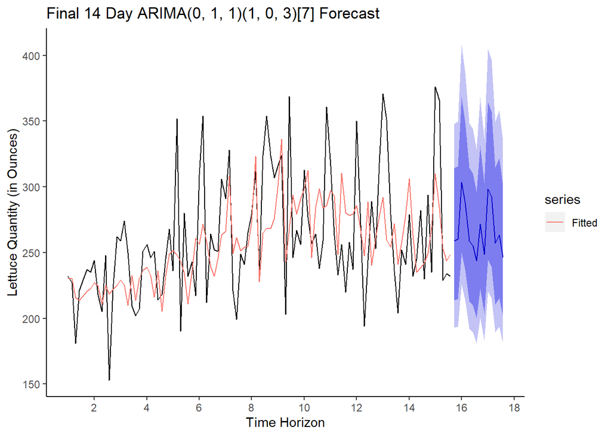

```r
## Best model plotted
autoplot(forecast_best_arima_store_12631, main = 'Final 14 Day ARIMA(0, 1, 1)(1, 0, 3)[7] Forecast', ylab = 'Lettuce Quantity (in Ounces)', xlab = 'Time Horizon') +
  autolayer(fitted(forecast_best_arima_store_12631), series = 'Fitted', na.rm=TRUE) +
  scale_x_continuous(breaks = seq(0, 22, by = 2)) +
  theme(panel.grid.major = element_blank(), panel.grid.minor = element_blank(), panel.background = element_blank(), axis.line = element_line(colour = "black")) +
  scale_y_continuous(breaks = c(100, 150, 200, 250, 300, 350, 400, 450, 500, 550))
```

### Forecast Further Improvements

The model must be checked by a residual analysis to see for further improvements. Much like the ETS model, there needs to be no correlations between the forecast errors of the model in the time series.

The Ljung-Box test statistic considers the first “h” autocorrelations values together. A significant test (small p-value) indicates the data are probably not white noise. The test is perfomed on lags 1 - 20 and the the null hypothesis is the independence of the time series. The Box.test() results in a test statistic of 13.58 and a p-value of 0.8507. These are large values and the null hypotheisis of indipenditely distributed forecast errors is accepted.

Using ggplots, ggACF() function, lags 1 - 19 are visually displayed. Obsebserving this ACF plot allows us to see that there is no serial autocorrelation between lags 1-19.

The forecast errors’ constant variance is tested by a time plot of the in-sample forecast errors, whereas their normal distribution with zero mean by a histogram plot of the forecast errors, with an overlaid normal curve that has mean zero and the same standard deviation as the distribution of forecast errors.

```r
## Ljung-Box Test
Box.test(forecast_best_arima_store_12631$residuals, lag = 20, type = 'Ljung-Box')
```

```
##
##  Box-Ljung test
##
## data:  forecast_best_arima_store_12631$residuals
## X-squared = 13.589, df = 20, p-value = 0.8507
```

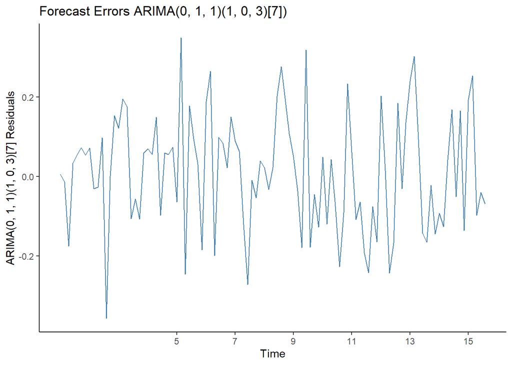

```r
## These plots are descriptive but they can be improved to increase interpretability by plotting and optimising each one individually
## Lets focus on the residuals plot in order to determine if they have constant variance (desired)

autoplot(forecast_best_arima_store_12631$residuals, main = 'Forecast Errors ARIMA(0, 1, 1)(1, 0, 3)[7])',
         ylab = 'ARIMA(0, 1, 1)(1, 0, 3)[7] Residuals', col = 'steelblue') +
  scale_x_continuous(breaks = seq(5, 22, by = 2)) +
  theme(panel.grid.major = element_blank(), panel.grid.minor = element_blank(),
        panel.background = element_blank(), axis.line = element_line(colour = "black"))
```

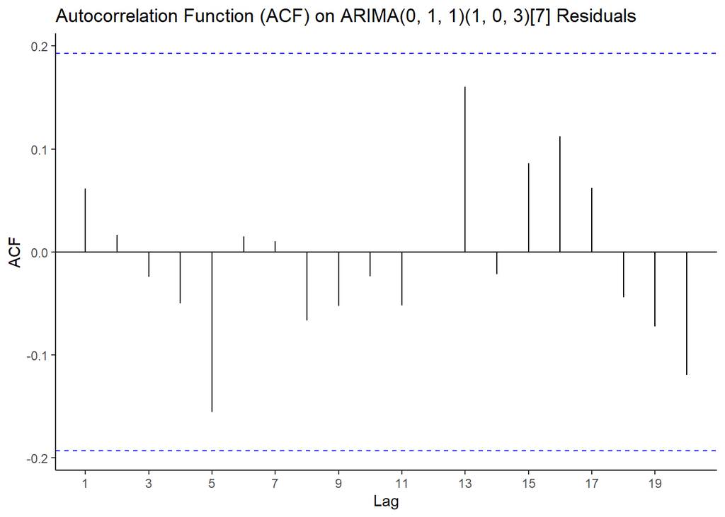

```r
## Next lets look at the ACF plot
ggAcf(forecast_best_arima_store_12631$residuals, main = 'Autocorrelation Function (ACF) on ARIMA(0, 1, 1)(1, 0, 3)[7] Residuals') +
  theme(panel.grid.major = element_blank(), panel.grid.minor = element_blank(),
        panel.background = element_blank(), axis.line = element_line(colour = "black")) +
  scale_x_continuous(breaks = seq(1, 100, by = 2))
```

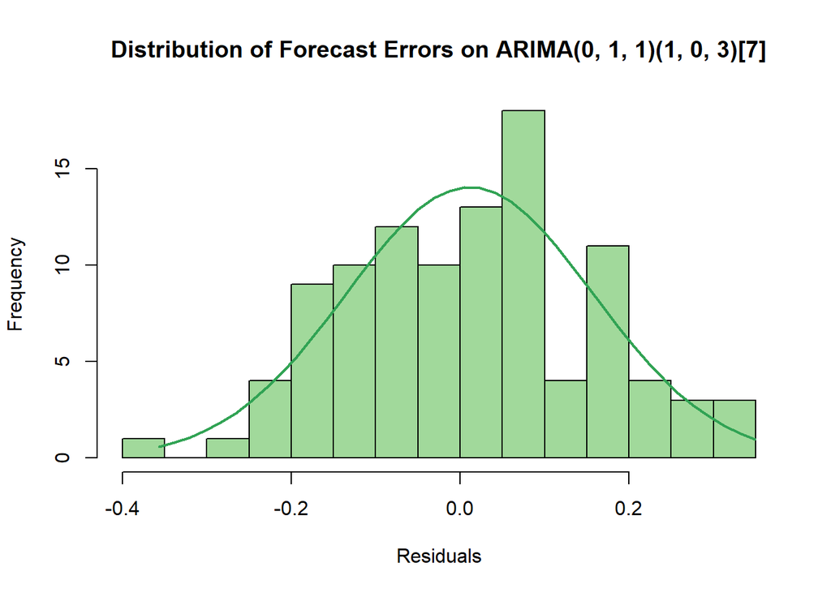

```r
h <- hist(forecast_best_arima_store_12631$residuals, breaks = 20, col = '#a1d99b',
          main = 'Distribution of Forecast Errors on ARIMA(0, 1, 1)(1, 0, 3)[7]', xlab = 'Residuals')
xfit<-seq(min(forecast_best_arima_store_12631$residuals),max(forecast_best_arima_store_12631$residuals),length=40)
yfit<-dnorm(xfit,mean=mean(forecast_best_arima_store_12631$residuals),sd=sd(forecast_best_arima_store_12631$residuals))
yfit <- yfit*diff(h$mids[1:2])*length(forecast_best_arima_store_12631$residuals)
lines(xfit, yfit,col="#31a354", lwd=2)
```

The plotted residuals and the histogram show that the forecast errors have constant variance over time and are normally distributed with mean of zero. It is conclusive that ARIMA(0, 1, 1)(1, 0, 3)[7] provides an adequate preditive model for the lettuce demand of store 12631.